# 16.Regression_Q slides

## Regression

### Da-Wei Chiang

## 大綱

- 何謂迴歸
- `Least Squares Method`
- `Regression Implement`
- `Regression Evaluate`

## 何謂迴歸

[figure not shown]

## `Least Squares Method`

## 範例資料

- 為了方便計算, 僅使用五筆資料為例

[figure not shown]

## 範例資料

- 上述資料為
  - `(22, 5)、(24, 20)、(26, 15)、(30, 30)、(32, 45)`
- 我們希望找到的方程式為`y=ax+b`
- 由範例資料我可以得到以下五條方程式
  - `22a+b=5`
  - `24a+b=20`
  - `26a+b=15`
  - `30a+b=30`
  - `32a+b=45`

## `Least Squares Method`

- 等號兩邊的平方差最小, 即下列求下列方程式的最小值 $$F = (5-(22a+b))^2 + (20-(24a+b))^2 + (15-(26a+b))^2 + (30-(30a+b))^2 + (45-(32a+b))^2 = 3660a^2+268ab−6640a+5b^2−230b+3575$$
- 該方程式的最小值即為對`a`及`b`進行偏微分

## `Least Squares Method`

- 偏微分 $$\frac{\partial F}{\partial a} = 7320a+268b-6640 = 0$$ $$\frac{\partial F}{\partial b} = 268a+10b-230 = 0$$

## `Least Squares Method`

- 解聯立方程式 $$x\approx3.4593$$ $$b\approx-69.709$$
- 迴歸線 $$y = 3.4593x-69.709 $$

## `Numpy`實作`Least Squares Method`

```
np.polyfit(x, y, deg)

##參數說明
## x = column data
## y = target data
## deg = 多項式的最高次方
```

```python
## 剛剛的理論範例 - (22, 5)、(24, 20)、(26, 15)、(30, 30)、(32, 45)
import numpy as np

x = np.array([22, 24, 26, 30, 32])
y = np.array([5, 20, 15, 30, 45])

a, b = np.polyfit(x, y, 1)

print('斜率a = ', a)
print('截距b = ', b)
print('方程式 y = ', a, 'x + ', b, sep='')
```

```
斜率a =  3.4593023255813966
截距b =  -69.70930232558143
方程式 y = 3.4593023255813966x + -69.70930232558143
```

## 練習 - 產生假資料

- 請自行產生`10`筆測試資料
  - 這`10`筆資料有個欄位X的範圍為`20～34`, 並隨機產生一個`Y`值
- 使用`matplotlib`將`X, Y`繪製為散步圖並呈現

## 承上題練習 - `polyfit`產生迴歸線

- 承上題
  - 請自行產生10筆測試資料
  - 這10筆資料有個欄位X的範圍為20～34, 並隨機產生一個Y值
  - 使用matplotlib將X, Y繪製為散步圖並呈現
- 使用上題產生的`X, Y`資料計算迴歸線, 並將迴歸線與資料點使用`matplotlib`繪製圖形

## 請想想`Regression`需要評估準確率嗎？

## `Regression Evaluate`

## `Evaluate`

[figure not shown]

## `Evaluate`

$$MAE = \frac{1}{N} \sum_{i=1}^n |y_i - \hat{y}_i|$$$$MSE = \frac{1}{N} \sum_{i=1}^n (y_i - \hat{y}_i)^2$$$$RMSE = \sqrt {\frac{1}{N} \sum_{i=1}^n (y_i - \hat{y}_i)^2}$$$$R^2 = \frac{\sum_{i=1}^n(y_i-\hat{y})^2}{\sum_{i=1}^n(y_i-\bar{y})^2}$$

## `Evaluate Implement`

```
from sklearn.metrics import mean_squared_error
from sklearn.metrics import mean_absolute_error
from sklearn.metrics import r2_score

mean_squared_error(y_test, y_predict)
mean_absolute_error(y_test, y_predict)
r2_score(y_test, y_predict)
```

## 承上題練習 - 評估準確率

- 承上題
  - 請自行產生10筆測試資料
  - 這10筆資料有個欄位X的範圍為20～34, 並隨機產生一個Y值
  - 使用matplotlib將X, Y繪製為散步圖並呈現
  - 使用上題產生的`X, Y`資料計算迴歸線, 並將迴歸線與資料點使用`matplotlib`繪製圖形
- 請評估上述迴歸線的準確率

## 上述的迴歸都只對一個`column`進行預測.

## 在真實資料上似乎不太實用.

## 想一想我們可否對多個`column`進行迴歸分析？

## 線性迴歸與多元線性迴歸

- 一個自變數(特徵值)和一個因變數(目標變數), 我們稱為簡單線性回歸
- 這樣的線性迴歸概念我們可以擴展為多個自變數(特徵值), 我們稱為多元線性迴歸. 又稱複迴歸.
  - 表示式：$$y = B_0 + B_1x_1 + B_2x_2 + ... + B_nx_n $$
- 多元線性迴歸
  - 使用`sklearn LinearRegression Model Training`

## SKLearn Implement - Training

```
from sklearn.linear_model import LinearRegression

Regression_Variable = LinearRegression()
...fit()
...predict()
```

```python
## 一個欄位的線性迴歸
## 剛剛的理論範例 - (22, 5)、(24, 20)、(26, 15)、(30, 30)、(32, 45)

from sklearn.linear_model import LinearRegression
import numpy as np
X = np.array([22, 24, 26, 30, 32])
Y = np.array([5, 20, 15, 30, 45])
Linear_Model = LinearRegression()
Linear_Model.fit(X.reshape(len(X), 1), Y.reshape(len(Y), 1))
print("斜率 = ", Linear_Model.coef_)  #係數
print("截拒 = ", Linear_Model.intercept_ )  #截拒
print("方程式 y = ", Linear_Model.coef_, 'X+', Linear_Model.intercept_)

## 預測資料
print('X = 25, 手算結果 = ', 25*3.45930233+(-69.70930233))
print('X = 25, 模型預測結果 = ', end='')
X_Predict = np.array([25])
predicted = Linear_Model.predict(X_Predict.reshape(len(X_Predict), 1))
print(predicted)
```

```
斜率 =  [[3.45930233]]
截拒 =  [-69.70930233]
方程式 y =  [[3.45930233]] X+ [-69.70930233]
X = 25, 手算結果 =  16.773255919999997
X = 25, 模型預測結果 = [[16.77325581]]
```

## 練習 - 產生一個特徵值的假資料並訓練

- 請使用`make_regression`函數建構資料(100筆資料、1個特徵值、30雜訊), 使用如下
- `Training Model`, 並評估模型準確率

```
from sklearn.datasets import make_regression #引用

X,Y=make_regression(n_samples, n_features, noise)

# n_samples:樣本數
# n_features:特徵值
# noise:雜訊
```

## 練習

- 請使用`make_regression`函數建構資料(100筆資料、10個特徵值、50雜訊), 使用如下
- `Training Model`, 並評估模型準確率

## 多項式迴歸

- 一次方程式所配適的迴歸結果為一條線、一個平面...等等. 雖然可以產生迴歸線的結果.
- 但二次、三次...等等的數據擬合效果卻可能比一次方程式來的好.
- 如:
  - 一元一次方程式$y = b_0 + b_1x+ε $
  - 一元二次方程式$y = b_0 + b_1x+b_2x^2+ε $
  - 一元三次方程式$y = b_0 + b_1x+b_2x^2+b_3x^3+ε $
  - 一元N次方程式$y = b_0 + b_1x+b_2x^2+b_3x^3+...+b_nx^n+ε $

## `sklearn`生成高維度特徵項

```
from sklearn.preprocessing import PolynomialFeatures

Poly_Variable = PolynomialFeatures(degree)
X_Poly = Poly_Variable.fit_transform(data)   #calc data
Poly_Variable.get_feature_names_out()   #X dim
```

```python
## 範例

import numpy as np
from sklearn.preprocessing import PolynomialFeatures

X = np.array([[1], [2], [3], [4]])

polynomial = PolynomialFeatures(2)
X_polynomial = polynomial.fit_transform(X)

print('次方項', polynomial.get_feature_names_out())
print(X_polynomial)
print('- - - - - - -')
polynomial = PolynomialFeatures(3)
X_polynomial = polynomial.fit_transform(X)

print('次方項', polynomial.get_feature_names_out())
print(X_polynomial)
```

```
次方項 ['1' 'x0' 'x0^2']
[[ 1.  1.  1.]
 [ 1.  2.  4.]
 [ 1.  3.  9.]
 [ 1.  4. 16.]]
- - - - - - -
次方項 ['1' 'x0' 'x0^2' 'x0^3']
[[ 1.  1.  1.  1.]
 [ 1.  2.  4.  8.]
 [ 1.  3.  9. 27.]
 [ 1.  4. 16. 64.]]
```

## 練習

- 請自行練習`PolynomialFeatures`方法

## 多項式特徵應用於`LinearRegression`

```
R^2 =  0.9017246194665548
```

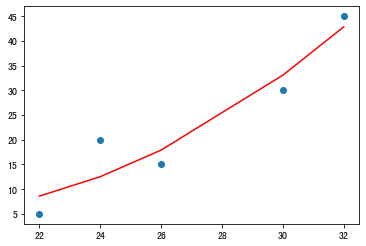

```
R^2 =  0.959225625734174
```

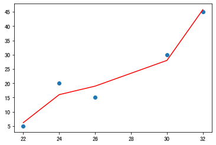

```python
## 剛剛的理論範例 - (22, 5)、(24, 20)、(26, 15)、(30, 30)、(32, 45)
import numpy as np
from sklearn.linear_model import LinearRegression
from sklearn.metrics import r2_score
import matplotlib.pyplot as plt

X = np.array([[22], [24], [26], [30], [32]])
y = np.array([[5], [20], [15], [30], [45]])

## 生成一元二次特徵
polynomial = PolynomialFeatures(2)
X_polynomial = polynomial.fit_transform(X)

## Train Model
model = LinearRegression()
model.fit(X_polynomial, y)
y_poly_pred = model.predict(X_polynomial)
print('R^2 = ', r2_score(y, y_poly_pred))
plt.plot(X, y_poly_pred, color='r')
plt.scatter(X, y)
plt.show()
## 生成一元三次特徵
polynomial = PolynomialFeatures(3)
X_polynomial = polynomial.fit_transform(X)

## Train Model
model = LinearRegression()
model.fit(X_polynomial, y)
y_poly_pred = model.predict(X_polynomial)
print('R^2 = ', r2_score(y, y_poly_pred))

plt.plot(X, y_poly_pred, color='r')
plt.scatter(X, y)
plt.show()
```

## 由上例我們發現, 隨著次方項提高, 迴歸線會越擬合資料點.

## 這樣的特性使`R`平方判定係數提高. 迴歸線越準確.

## 但這樣的方式要小心產生`overfitting`的狀況

## 練習

- 請使用波士頓房價資料集.
- 建構迴歸模型預測波士頓房價
- 並評估其結果